# Stanford CME 241 (Winter 2026) - Assignment 1

**Due: Friday, January 23 @ 11:59 PM PST on Gradescope.**

Assignment instructions:

- Make sure each of the subquestions have answers
- Ensure that group members indicate which problems they're in charge of
- Show work and walk through your thought process where applicable
- Empty code blocks are for your use, so feel free to create more under each section as needed
- Document code with light comments (i.e. 'this function handles visualization')

Submission instructions:

- When complete, fill out your publicly available GitHub repo file URL and group members below, then export or print this .ipynb file to PDF and upload the PDF to Gradescope.

*Link to this ipynb file in your public GitHub repo (replace below URL with yours):*

https://github.com/yuxiang-jack-zhang/CME241/blob/master/assignment1/assignment1.ipynb

*Group members (replace below names with people in your group):*

- Jack Zhang
- Jeffrey Xue
- Patrick Flanagan

## Imports

```python
import os
os.chdir('..')

from rl.markov_process import FiniteMarkovProcess, NonTerminal, Terminal
from rl.distribution import Categorical
import numpy as np
from collections import defaultdict
import itertools
import matplotlib.pyplot as plt
```

## Question 1: Snakes and Ladders (Led by Jeffrey Xue)

In the classic childhood game of Snakes and Ladders, all players start to the left of square 1 (call this position 0) and roll a 6-sided die to represent the number of squares they can move forward. The goal is to reach square 100 as quickly as possible. Landing on the bottom rung of a ladder allows for an automatic free-pass to climb, e.g. square 4 sends you directly to 14; whereas landing on a snake's head forces one to slide all the way to the tail, e.g. square 34 sends you to 6. Note, this game can be viewed as a Markov Process, where the outcome is only depedent on the current state and not the prior trajectory. In this question, we will ask you to both formally describe the Markov Process that describes this game, followed by coding up a version of the game to get familiar with the RL-book libraries.

### Problem Statement

How can we model this problem with a Markov Process?

### Subquestions

#### Part (A): MDP Modeling

Formalize the state space of the Snakes and Ladders game. Don't forget to specify the terminal state!

#### Part (B): Transition Probabilities

Write out the structure of the transition probabilities. Feel free to abbreviate all squares that do not have a snake or ladder.

#### Part (C): Modeling the Game

Code up a `transition_map: Transition[S]` data structure to represent the transition probabilities of the Snakes and Ladders Markov Process so you can model the game as an instance of `FiniteMarkovProcess`. Use the `traces` method to create sampling traces, and plot the graph of the distribution of time steps to finish the game. Use the image provided for the locations of the snakes and ladders.

https://drive.google.com/file/d/1yhP242sG092Ico_WOPKrUp8jVJHbuGHH/view?usp=sharing

### Part (A) Answer

The countable entire set of states is ${S} = \{0,1,2,3,\ldots 100\}$. Among those, the terminal state set is ${T} = \{100\}$.

In plain English, the state space is all the squares on the 10 x 10 grid plus the initial starting state (position 0). The only terminal state is the last square (position 100) where the game ends.

### Part (B) Answer

Let ${A} \subseteq {S}$ be the set of states where each state is neither at the bottom of a ladder or the top of a snake (the head). Let ${B} = {S} - {A}$, or the states that have a snake or ladder. Let $f: {B} \rightarrow {A}$ map the states that have snakes or ladders to the state at the other end of the snake or ladder.

With this setup, the transition probability function for all $ s \in {N}$ and $i \in \{1,2,3,4,5,6\}$ is: $$\text{if } (s+i) \in {A} \text{: } \mathbb{P}[s+i | s] = \frac{1}{6}$$ $$\text{otherwise } (s+i) \in {B} \text{: } \mathbb{P}[f(s+i) | s] = \frac{1}{6}$$ The transition probabilities are 0 everywhere else.

### Part (C) Answer

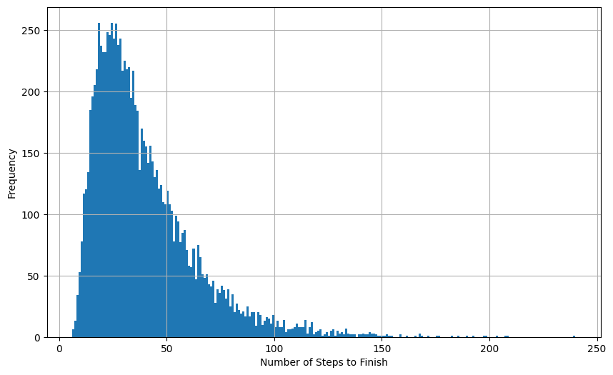

```python
f = {
    1: 38,
    4: 14,
    8: 30,
    21: 42,
    28: 76,
    50: 67,
    71: 92,
    80: 99,
    32: 10,
    36: 6,
    48: 26,
    62: 18,
    88: 24,
    95: 56,
    97: 78
}

transition_map = {}
for position in range(100):
    next_probs = defaultdict(float)
    for roll in range(1, 7):
        next_position = position + roll
        if next_position > 100:
            next_position = position
        next_position = f.get(next_position, next_position)
        next_probs[next_position] += 1/6
    transition_map[position] = Categorical(next_probs)

snakes_ladders_mp = FiniteMarkovProcess(transition_map)
start_dist = Categorical({NonTerminal(0): 1.0})

num_traces = 10000
traces = [list(trace) for trace in itertools.islice(snakes_ladders_mp.traces(start_dist), num_traces)]
steps_tally = []
for trace in traces:
    states = trace
    steps = len(states) - 1
    steps_tally.append(steps)

plt.figure(figsize=(10, 6))
plt.hist(steps_tally, bins=range(min(steps_tally), max(steps_tally) + 2))
plt.xlabel('Number of Steps to Finish')
plt.ylabel('Frequency')
plt.grid(True)
plt.show()
```

## Question 2: Markov Decision Processes (Led by Patrick Flanagan)

Consider an MDP with an infinite set of states ${S} = \{1,2,3,\ldots \}$. The start state is $s=1$. Each state $s$ allows a continuous set of actions $a \in [0,1]$. The transition probabilities are given by: $$\mathbb{P}[s+1 \mid s, a] = a, \mathbb{P}[s \mid s, a] = 1 - a \text{ for all } s \in S \text{ for all } a \in [0,1]$$ For all states $s \in {S}$ and actions $a \in [0,1]$, transitioning from $s$ to $s+1$ results in a reward of $1-a$ and transitioning from $s$ to $s$ results in a reward of $1+a$. The discount factor $\gamma=0.5$.

### Problem Statement

How can we derive a mathematical formulation for the value function and the optimal policy? And how do those functions change when we modify the action space?

### Subquestions

#### Part (A): Optimal Value Function

Using the MDP Bellman Optimality Equation, calculate the Optimal Value Function $V^*(s)$ for all $s \in {S}$. Given $V^*(s)$, what is the optimal action, $a^*$, that maximizes the optimal value function?

#### Part (B): Optimal Policy

Calculate an Optimal Deterministic Policy $\pi^*(s)$ for all $s \in {S}$.

#### Part (C): Changing the Action Space

Let's assume that we modify the action space such that instead of $a \in [0,1]$ for all states, we restrict the action space to $a \in \left[0,\frac{1}{s}\right]$ for state $s$. This means that higher states have more restricted action spaces. How does this constraint affect:

- The form of the Bellman optimality equation?
- The optimal value function, $V^*(s)$?
- The structure of the optimal policy, $\pi^*(s)$?

### Part (A) Answer

**Starting with the Bellman Optimality Equation:**

$$V^*(s) = \max_{a \in [0,1]} \mathbb{E}\left[R(s,a,S') + \gamma V^*(S') \mid S=s\right]$$

**Expanding the expectation:**

$$V^*(s) = \max_{a \in [0,1]} \left\{ a\left[(1-a) + \gamma V^*(s+1)\right] + (1-a)\left[(1+a) + \gamma V^*(s)\right] \right\}$$

Since the reward structure and transitions are the same for all states, the optimal value function is stationary: $V^*(s) = V^*(s+1) = V^*$ for all $s$.

**Substituting:**

$$V^* = \max_{a \in [0,1]} \left\{ a(1-a) + (1-a)(1+a) + \gamma V^* \right\}$$

**Simplifying the reward term:**

$$a(1-a) + (1-a)(1+a) = a - a^2 + 1 - a^2 = 1 + a - 2a^2$$

**So we have:**

$$(1-\gamma)V^* = \max_{a \in [0,1]} (1 + a - 2a^2)$$

**With $\gamma = 0.5$:**

$$0.5 \cdot V^* = \max_{a \in [0,1]} (1 + a - 2a^2)$$

**Finding the optimal action by taking the derivative:**

$$f(a) = 1 + a - 2a^2$$ $$f'(a) = 1 - 4a = 0 \implies \boxed{a^* = \frac{1}{4}}$$

**Evaluating at the optimum:**

$$f\left(\frac{1}{4}\right) = 1 + \frac{1}{4} - 2\left(\frac{1}{16}\right) = 1 + \frac{1}{4} - \frac{1}{8} = \frac{9}{8}$$

**Solving for V*:**

$$0.5 \cdot V^* = \frac{9}{8} \implies \boxed{V^*(s) = \frac{9}{4} \text{ for all } s \in \mathcal{S}}$$

### Part (B) Answer

From Part (A), we found that the optimal action $a^* = \frac{1}{4}$ maximizes the value function, and this result is independent of the state $s$ (due to the stationary structure of the MDP).

**Optimal Deterministic Policy:**

$$\boxed{\pi^*(s) = \frac{1}{4} \text{ for all } s \in \{1, 2, 3, \ldots\}}$$

**Justification:**

- The transition probabilities $\mathbb{P}[s+1|s,a] = a$ and $\mathbb{P}[s|s,a] = 1-a$ are identical for all states
- The reward structure (reward $1-a$ for moving forward, reward $1+a$ for staying) is also identical for all states
- Therefore, the optimal action does not depend on which state the agent is in
- The agent should always choose $a = \frac{1}{4}$, which balances the trade-off between:
  - Higher probability of staying (getting reward $1+a$)
  - Lower immediate reward when moving forward (reward $1-a$)

### Part (C) Answer

#### Bellman Optimality Equation Change:

The Bellman equation now has a state-dependent action constraint:

$$V^*(s) = \max_{a \in [0, \frac{1}{s}]} \left\{ a\left[(1-a) + \gamma V^*(s+1)\right] + (1-a)\left[(1+a) + \gamma V^*(s)\right] \right\}$$

The only change is the upper bound of the action space: instead of $a \in [0,1]$, we now have $a \in [0, \frac{1}{s}]$.

#### Optimal Value Function Change:

From Part (A), the unconstrained optimal action is $a^* = \frac{1}{4}$. Now we must check whether this action is feasible under the new constraint:

- If $\frac{1}{s} \geq \frac{1}{4}$ (i.e., $s \leq 4$): The unconstrained optimum $a^* = \frac{1}{4}$ is feasible, so $V^*(s) = \frac{9}{4}$
- If $\frac{1}{s} < \frac{1}{4}$ (i.e., $s > 4$): The constraint binds, and we must take $a = \frac{1}{s}$

For $s > 4$, the value function satisfies:

$$V^*(s) = a^*(s)(1-a^*(s)) + (1-a^*(s))(1+a^*(s)) + \gamma\left[a^*(s)V^*(s+1) + (1-a^*(s))V^*(s)\right]$$

where $a^*(s) = \frac{1}{s}$.

The sequence $\{V^*(s)\}_{s \geq 1}$ must be solved recursively, with $V^*(s) = \frac{9}{4}$ for $s \leq 4$ as the boundary condition.

#### Optimal Policy Change:

$$\boxed{\pi^*(s) = a^*(s) = \min\left(\frac{1}{4}, \frac{1}{s}\right)}$$

## Question 3: Frog in a Pond (Led by Jack Zhang)

Consider an array of $n+1$ lilypads on a pond, numbered $0$ to $n$. A frog sits on a lilypad other than the lilypads numbered $0$ or $n$. When on lilypad $i$ ($1 \leq i \leq n-1$), the frog can croak one of two sounds: **A** or **B**.

- If it croaks **A** when on lilypad $i$ ($1 \leq i \leq n-1$):
  - It is thrown to lilypad $i-1$ with probability $\frac{i}{n}$.
  - It is thrown to lilypad $i+1$ with probability $\frac{n-i}{n}$.
- If it croaks **B** when on lilypad $i$ ($1 \leq i \leq n-1$):
  - It is thrown to one of the lilypads $0, \ldots, i-1, i+1, \ldots, n$ with uniform probability $\frac{1}{n}$.

A snake, perched on lilypad $0$, will eat the frog if it lands on lilypad $0$. The frog can escape the pond (and hence, escape the snake!) if it lands on lilypad $n$.

### Problem Statement

What should the frog croak when on each of the lilypads $1, 2, \ldots, n-1$, in order to maximize the probability of escaping the pond (i.e., reaching lilypad $n$ before reaching lilypad $0$)?

Although there are multiple ways to solve this problem, we aim to solve it by modeling it as a **Markov Decision Process (MDP)** and identifying the **Optimal Policy**.

### Subquestions

#### Part (A): MDP Modeling

Express the frog-escape problem as an MDP using clear mathematical notation by defining the following components:

- **State Space**: Define the possible states of the MDP.
- **Action Space**: Specify the actions available to the frog at each state.
- **Transition Function**: Describe the probabilities of transitioning between states for each action.
- **Reward Function**: Specify the reward associated with the states and transitions.

#### Part (B): Python Implementation

There is starter code below to solve this problem programatically. Fill in each of the $6$ `TODO` areas in the code. As a reference for the transition probabilities and rewards, you can make use of the example in slide 16/31 from the following slide deck: https://github.com/coverdrive/technical-documents/blob/master/finance/cme241/Tour-MP.pdf.

Write Python code that:

- Models this MDP.
- Solves the **Optimal Value Function** and the **Optimal Policy**.

Feel free to use/adapt code from the textbook. Note, there are other libraries that are needed to actually run this code, so running it will not do anything. Just fill in the code so that it could run assuming that the other libraries are present.

#### Part (C): Visualization and Analysis

What patterns do you observe for the **Optimal Policy** as you vary $n$ from $3$ to $25$? When the frog is on lilypad $13$ (with $25$ total), what action should the frog take? Is this action different than the action the frog should take if it is on lilypad $1$?

### Part (A) Answer

#### State Space:

$\mathcal{S} = \{0,1,\dots, n\}$

#### Action Space:

$\mathcal{A}(s) = \begin{cases}\{A, B\} \text{ for } 1 \leq s \leq n-1\\\emptyset\text{ otherwise}\end{cases}$

#### Transition Function:

Define transition function $\mathcal{T}(s, a, s')$ as follows.

For any $a\in \mathcal{A}$:

$\mathcal{T}(0, a, s') = \begin{cases}1 \quad \text{ if } s'=0=s\\ 0 \quad \text{ otherwise}\end{cases}$

$\mathcal{T}(n, a, s') = \begin{cases}1 \quad \text{ if } s'=n=s\\ 0 \quad \text{ otherwise}\end{cases}$

For $1 \leq i \leq n-1$:

$\mathcal{T}(s, A, s') = \begin{cases}\frac{s}{n} \quad \text{ if } s'=s-1\\\frac{n-s}{n} \quad \text{ if } s'=s+1\\0 \quad \text{ otherwise}\end{cases}$

$\mathcal{T}(s, B, s') = \begin{cases}\frac{1}{n} \quad \text{ for } 0\leq s' \leq n \text{ and } s'\neq s\\0 \quad s'=s\end{cases}$

#### Reward Function:

$\mathcal{R}(s, a, s') = \begin{cases}1 \quad \text{ if }s'=n\\-1 \quad \text{ if } s'=0\\0 \quad \text{ otherwise}\end{cases}$

### Part (B) Answer

```python
Gamma = float
Transitions = dict
MDPRefined = tuple[Transitions, Gamma]
def get_lily_pads_mdp(n: int) -> MDPRefined:
    data = {
        i: {
            'A': {
                i - 1: i/n,
                i + 1: (n-i)/n,
            },
            'B': {
                j: 1./n
                for j in range(0, n+1) if j != i
            }
        } for i in range(1, n)
    }
    # terminal states
    data[0] = {}
    data[n] = {}

    gamma = 1.0
    return data, gamma

Mapping = dict
Policy = Mapping[int, str]
Value = Mapping[int, float]
def solve_lily_pads_mdp(n: int) -> tuple[Value, Policy]:
    transitions, gamma = get_lily_pads_mdp(n)

    vf = [0.5] * (n + 1)
    vf[0] = 0.
    vf[n] = 0.

    pi = [None] * (n + 1)

    tol = 1e-8
    epsilon = tol * 1e4
    while epsilon >= tol:
        old_vf = [v for v in vf]
        for i in range(1, n):
            # Bellman update: max Vf over all actions
            v_A = sum(transitions[i]["A"][j] * (float(j == n) - float(j == 0) + gamma * old_vf[j]) for j in [i-1,i+1]) # action A
            v_B = sum(transitions[i]["B"][j] * (float(j == n) - float(j == 0) + gamma * old_vf[j]) for j in range(0, n+1) if j != i) # action B
            vf[i] = max(v_A, v_B)
            pi[i] = "A" if v_A > v_B else "B"
        epsilon = max(abs(old_vf[i] - v) for i, v in enumerate(vf))
    return {v: f for v, f in enumerate(vf)}, {i: a for i, a in enumerate(pi)}
```

```python
n = 25
optimal_value, optimal_policy = solve_lily_pads_mdp(n)
print("state - optimal action - optimal value")
for i in range(n):
    print(f"{i} - {optimal_policy[i]} - {optimal_value[i]}")
```

```
state - optimal action - optimal value
0 - None - 0.0
1 - B - 0.4225180763487227
2 - A - 0.45497318571940215
3 - A - 0.45779536295258483
4 - A - 0.45818019398196536
5 - A - 0.4582534885109984
6 - A - 0.4582717996460268
7 - A - 0.45827757479858355
8 - A - 0.45827980680283653
9 - A - 0.45828084898700117
10 - A - 0.45828141959074725
11 - A - 0.45828179073313813
12 - A - 0.45828206448793585
13 - A - 0.45828230649997825
14 - A - 0.4582825478463797
15 - A - 0.4582828423871909
16 - A - 0.45828325919841295
17 - A - 0.45828398476276394
18 - A - 0.45828549533704455
19 - A - 0.45828935982808944
20 - A - 0.4583015557168213
21 - A - 0.458350311492638
22 - A - 0.4586062168232997
23 - A - 0.4604828096423576
24 - A - 0.48206350256877223
```

### Part (C) Answer

The pattern I observed is to croak B on lilypad 1, and croak A elsewhere.

This action is different than the action the frog should take if it is on lilypad $1$, which is Action B. Action B has the same probability of going to death as Action A of $\frac{1}{25}$, but Action B has some probability that the frog can jump to a high-numbered lilypad too and escape the beginning area, or even straight to lilypad $25$, while Action A will keep the frog near the low-numbered lilypad area. Thus, taking the risk with Action B seems more favorable on lilypad $1$.

## Question 4: Manual Value Iteration (Led by Jeffrey Xue)

Consider a simple MDP with ${S} = \{s_1, s_2, s_3\}, {T} = \{s_3\}, {A} = \{a_1, a_2\}$. The State Transition Probability function
$${P}: {N} \times {A} \times {S} \rightarrow [0, 1]$$ is defined as:
$${P}(s_1, a_1, s_1) = 0.25, {P}(s_1, a_1, s_2) = 0.65, {P}(s_1, a_1, s_3) = 0.1$$ $${P}(s_1, a_2, s_1) = 0.1, {P}(s_1, a_2, s_2) = 0.4, {P}(s_1, a_2, s_3) = 0.5$$ $${P}(s_2, a_1, s_1) = 0.3, {P}(s_2, a_1, s_2) = 0.15, {P}(s_2, a_1, s_3) = 0.55$$ $${P}(s_2, a_2, s_1) = 0.25, {P}(s_2, a_2, s_2) = 0.55, {P}(s_2, a_2, s_3) = 0.2$$

The Reward Function
$${R}: {N} \times {A} \rightarrow \mathbb{R}$$ is defined as:
$${R}(s_1, a_1) = 8.0, {R}(s_1, a_2) = 10.0$$ $${R}(s_2, a_1) = 1.0, {R}(s_2, a_2) = -1.0$$

Assume a discount factor of $\gamma = 1$.

### Problem Statement

Your task is to determine an Optimal Deterministic Policy **by manually working out** (not with code) the first two iterations of the Value Iteration algorithm.

### Subquestions

#### Part (A): 2 Iterations

1. Initialize the Value Function for each state to be its $\max$ (over actions) reward, i.e., we initialize the Value Function to be $v_0(s_1) = 10.0, v_0(s_2) = 1.0, v_0(s_3) = 0.0$. Then manually calculate $q_k(\cdot, \cdot)$ and $v_k(\cdot)$ from $v_{k - 1}(\cdot)$ using the Value Iteration update, and then calculate the greedy policy $\pi_k(\cdot)$ from $q_k(\cdot, \cdot)$ for $k = 1$ and $k = 2$ (hence, 2 iterations).

#### Part (B): Argument

1. Now argue that $\pi_k(\cdot)$ for $k > 2$ will be the same as $\pi_2(\cdot)$. *Hint*: You can make the argument by examining the structure of how you get $q_k(\cdot, \cdot)$ from $v_{k-1}(\cdot)$. With this argument, there is no need to go beyond the two iterations you performed above, and so you can establish $\pi_2(\cdot)$ as an Optimal Deterministic Policy for this MDP.

#### Part (C): Policy Evaluation

1. Using the policy $\pi_2(\cdot)$, compute the exact value function $V^{\pi_2}(s)$ for all $s\in S$.

#### Part (D): Sensitivity Analysis

Assume the reward for $R(s_1, a_2)$ is modified to $11.0$ instead of $10.0$.

1. Perform one iteration of Value Iteration starting from the initialized value function $v_0(s)$, where $v_0(s)$ remains the same as in the original problem.
2. Determine whether this change impacts the Optimal Deterministic Policy $\pi(\cdot)$. If it does, explain why.

### Part (A) Answer

Starting with $v_0(s_1) = 10.0, v_0(s_2) = 1.0, v_0(s_3) = 0.0$ and using $\gamma = 1$.

Iteration 1 ($k=1$):

For $s_1$:

- $q_1(s_1, a_1) = 8.0 + 1.0 \cdot (0.25 \cdot 10.0 + 0.65 \cdot 1.0 + 0.1 \cdot 0.0) = 8.0 + 3.15 = 11.15$
- $q_1(s_1, a_2) = 10.0 + 1.0 \cdot (0.1 \cdot 10.0 + 0.4 \cdot 1.0 + 0.5 \cdot 0.0) = 10.0 + 1.4 = 11.4$
- the best action that maximizes $q$ is $a_2$, so $\pi_1(s_1) = a_2$ and $v_1(s_1) = 11.4$

For $s_2$:

- $q_1(s_2, a_1) = 1.0 + 1.0 \cdot (0.3 \cdot 10.0 + 0.15 \cdot 1.0 + 0.55 \cdot 0.0) = 1.0 + 3.15 = 4.15$
- $q_1(s_2, a_2) = -1.0 + 1.0 \cdot (0.25 \cdot 10.0 + 0.55 \cdot 1.0 + 0.2 \cdot 0.0) = -1.0 + 3.05 = 2.05$
- the best action that maximizes $q$ is $a_1$, so $\pi_1(s_2) = a_1$ and $v_1(s_2) = 4.15$

Iteration 2 ($k=2$):

For $s_1$:

- $q_2(s_1, a_1) = 8.0 + 1.0 \cdot (0.25 \cdot 11.4 + 0.65 \cdot 4.15 + 0.1 \cdot 0.0) = 8.0 + 5.5475 = 13.5475$
- $q_2(s_1, a_2) = 10.0 + 1.0 \cdot (0.1 \cdot 11.4 + 0.4 \cdot 4.15 + 0.5 \cdot 0.0) = 10.0 + 2.8 = 12.8$
- the best action that maximizes $q$ is $a_1$, so $\pi_2(s_1) = a_1$ and $v_2(s_1) = 13.5475$

For $s_2$:

- $q_2(s_2, a_1) = 1.0 + 1.0 \cdot (0.3 \cdot 11.4 + 0.15 \cdot 4.15 + 0.55 \cdot 0.0) = 1.0 + 4.0425 = 5.0425$
- $q_2(s_2, a_2) = -1.0 + 1.0 \cdot (0.25 \cdot 11.4 + 0.55 \cdot 4.15 + 0.2 \cdot 0.0) = -1.0 + 5.1325 = 4.1325$
- the best action that maximizes $q$ is $a_1$, so $\pi_2(s_2) = a_1$ and $v_2(s_2) = 5.0425$

### Part (B) Answer:

By definition, we know $q_k(s, a) = R(s, a) + \sum_{s'} P(s, a, s') v_{k-1}(s')$ since $\gamma = 1$. We also see from the first two iterations that because $s_3$ is terminal, it will always have a value of 0 as we cannot update it past its original value. Thus, we see the structure of $q_k$ depends only on $v_{k-1}(s_1)$ and $v_{k-1}(s_2)$.

Furthermore, we see that the values of the first two states are now both positive and only increasing, and the optimal policy for both states is to pick action 1. Thus, after the second iteration, the relative ordering of $q_k(s_1, a_1)$ vs $q_k(s_1, a_2)$ and $q_k(s_2, a_1)$ vs $q_k(s_2, a_2)$ will remain the same. We see this from the definition of $q_k(s, a)$ because $R(s, a)$ and $P(s, a, s')$ are both fixed, and because taking action 1 from both states has higher transition probabilities to state 1 (which has much higher value than state 2), it will only push $v_{k-1}(s_1)$ and $v_{k-1}(s_2)$ to increase together in a coordinated manner. This growth favors taking action 1 from both states, which pushes the future iterations to further pursue action 1.

Thus, the policy $\pi_k$ for $k > 2$ converges and will be the same as $\pi_2$, namely: $\pi_k(s_1) = a_1$, $\pi_k(s_2) = a_1$.

### Part (C) Answer:

Using $\pi_2(s_1) = a_1$, $\pi_2(s_2) = a_1$ we get the following implementations of the Bellman Equation:

For $s_1$: $V^{\pi_2}(s_1) = 8.0 + 0.25 V^{\pi_2}(s_1) + 0.65 V^{\pi_2}(s_2)$

For $s_2$: $V^{\pi_2}(s_2) = 1.0 + 0.3 V^{\pi_2}(s_1) + 0.15 V^{\pi_2}(s_2)$

$V^{\pi_2}(s_3) = 0$ (terminal state)

Solving the system of the first two equations and two variables: $V^{\pi_2}(s_1) = 16.83$ and $V^{\pi_2}(s_2) = 7.12$, and of course $V^{\pi_2}(s_3) = 0$.

### Part (D) Answer

Starting with $v_0(s_1) = 10.0, v_0(s_2) = 1.0, v_0(s_3) = 0.0$ and using $\gamma = 1$.

Iteration 1 ($k=1$):

For $s_1$:

- $q_1(s_1, a_1) = 8.0 + 1.0 \cdot (0.25 \cdot 10.0 + 0.65 \cdot 1.0 + 0.1 \cdot 0.0) = 11.15$
- $q_1(s_1, a_2) = 11.0 + 1.0 \cdot (0.1 \cdot 10.0 + 0.4 \cdot 1.0 + 0.5 \cdot 0.0) = 12.4$
- the best action that maximizes $q$ is $a_2$, so $\pi_1(s_1) = a_2$ and $v_1(s_1) = 12.4$

For $s_2$:

- $q_1(s_2, a_1) = 1.0 + 1.0 \cdot (0.3 \cdot 10.0 + 0.15 \cdot 1.0 + 0.55 \cdot 0.0) = 4.15$
- $q_1(s_2, a_2) = -1.0 + 1.0 \cdot (0.25 \cdot 10.0 + 0.55 \cdot 1.0 + 0.2 \cdot 0.0) = 2.05$
- the best action that maximizes $q$ is $a_1$, so $\pi_1(s_2) = a_1$ and $v_1(s_2) = 4.15$

## Question 5: Fixed-Point and Policy Evaluation True/False Questions (Led by Patrick Flanagan)

### Recall Section: Key Formulas and Definitions

#### Bellman Optimality Equation

The Bellman Optimality Equation for state-value functions is: $$ V^*(s) = \max_a \left[ R(s, a) + \gamma \sum_{s'} P(s, a, s') V^*(s') \right]. $$ For action-value functions: $$ Q^*(s, a) = R(s, a) + \gamma \sum_{s'} P(s, a, s') \max_{a'} Q^*(s', a'). $$

#### Contraction Property

The Bellman Policy Operator $B^\pi$ is a contraction under the $L^\infty$-norm: $$ \|B^\pi(X) - B^\pi(Y)\|_\infty \leq \gamma \|X - Y\|_\infty. $$ This guarantees convergence to a unique fixed point.

#### Policy Iteration

Policy Iteration alternates between:

1. **Policy Evaluation**: Compute $V^\pi$ for the current policy $\pi$.
2. **Policy Improvement**: Generate a new policy $\pi'$ by setting: $$ \pi'(s) = \arg\max_a \left[ R(s, a) + \gamma \sum_{s'} P(s, a, s') V^\pi(s') \right]. $$

#### Discounted Return

The discounted return from time step $t$ is: $$ G_t = \sum_{i=t+1}^\infty \gamma^{i-t-1} R_i, $$ where $\gamma \in [0, 1)$ is the discount factor.

### True/False Questions (Provide Justification)

1. **True/False**: If $Q^\pi(s, a) = 5$, $P(s, a, s') = 0.5$ for $s' \in \{s_1, s_2\}$, and the immediate reward $R(s, a)$ increases by $2$, the updated action-value function $Q^\pi(s, a)$ also increases by $2$.
2. **True/False**: For a discount factor $\gamma = 0.9$, the discounted return for rewards $R_1 = 5, R_2 = 3, R_3 = 1$ is greater than $6$.
3. **True/False**: The Bellman Policy Operator $B^\pi(V) = R^\pi + \gamma P^\pi \cdot V$ satisfies the contraction property for all $\gamma \in [0, 1)$, ensuring a unique fixed point.
4. **True/False**: In Policy Iteration, the Policy Improvement step guarantees that the updated policy $\pi'$ will always perform strictly better than the previous policy $\pi$.
5. **True/False**: If $Q^\pi(s, a) = 10$ for all actions $a$ in a state $s$, then the corresponding state-value function $V^\pi(s) = 10$, regardless of the policy $\pi$.
6. **True/False**: The discounted return $G_t = \sum_{i=t+1}^\infty \gamma^{i-t-1} R_i$ converges to a finite value for any sequence of bounded rewards if $\gamma < 1$.

### Answers (Provide justification, brief explanations are fine)

#### Question 1:

**True.**

The action-value function is defined as:

$$Q^\pi(s,a) = R(s,a) + \gamma \sum_{s'} P(s,a,s') V^\pi(s')$$

The second term (the expected future value) depends only on transition probabilities and the value function, not on $R(s,a)$. Therefore, if $R(s,a)$ increases by 2, then $Q^\pi(s,a)$ increases by exactly 2.

#### Question 2:

**True.**

The discounted return is:

$$G_0 = R_1 + \gamma R_2 + \gamma^2 R_3 = 5 + 0.9(3) + 0.9^2(1) = 5 + 2.7 + 0.81 = 8.51 > 6$$

#### Question 3:

**True.**

The Bellman Policy Operator is:

$$B^\pi(V) = R^\pi + \gamma P^\pi V$$

For any two value functions $V$ and $W$:

$$\|B^\pi(V) - B^\pi(W)\|_\infty = \|\gamma P^\pi (V - W)\|_\infty \leq \gamma \|V - W\|_\infty$$

Since $\gamma < 1$, this is a contraction mapping, which by the Banach Fixed Point Theorem guarantees a unique fixed point.

#### Question 4:

**False.**

Policy Improvement guarantees that the new policy $\pi'$ is *at least as good as* (not worse than) the previous policy $\pi$, i.e., $V^{\pi'}(s) \geq V^\pi(s)$ for all $s$.

It does not guarantee *strict* improvement. If $\pi$ is already optimal, then $\pi' = \pi$ and no improvement occurs.

#### Question 5:

**True.**

The state-value function is the expectation of the action-value function under the policy:

$$V^\pi(s) = \sum_a \pi(a|s) Q^\pi(s,a)$$

If $Q^\pi(s,a) = 10$ for all actions $a$, then:

$$V^\pi(s) = \sum_a \pi(a|s) \cdot 10 = 10 \sum_a \pi(a|s) = 10$$

since $\sum_a \pi(a|s) = 1$ for any valid policy.

#### Question 6:

**True.**

If rewards are bounded (i.e., $|R_i| \leq M$ for some constant $M$), then:

$$|G_t| \leq \sum_{k=0}^{\infty} \gamma^k |R_{t+k+1}| \leq M \sum_{k=0}^{\infty} \gamma^k = \frac{M}{1-\gamma} < \infty$$

Since $\gamma < 1$, the geometric series converges, guaranteeing a finite return.